# EDA using WDI

ID Last, First

2024-01-10

# 1 Exploratory Data Analysis, EDA

## 1.1 About EDA

EDA is an iterative cycle that helps you understand what your data says. When you do EDA, you:

1. Generate questions about your data
2. Search for answers by visualising, transforming, and/or modeling your data
3. Use what you learn to refine your questions and/or generate new questions

EDA is an important part of any data analysis. You can use EDA to make discoveries about the world; or you can use EDA to ensure the quality of your data, asking questions about whether the data meets your standards or not. (Posit Primers: [EDA](https://posit.cloud/learn/primers/3.1))

## 1.2 Workflow

1. Importing data by WDI

```
df_dataframe_name <- WDI(indicators = c(name1 = "Indicator Code 1",
name2 = "Indicator Code 2"), extra = TRUE)
```

Write and read:

```
write_csv(df_dataframe_name, "data/dataframe_name.csv")
df_dataframe_name <- read_csv("data/dataframe_name.csv")
```

2. Viewing data by

`head()`, `str()`, `summary()`, and try `df_dataframe_name`. See also Environment Tab of RStudio.

3. Transforming data by restricting the values of a variable.

```
df_dataframe_name |> filter(var == "value")
df_dataframe_name |> filter(var %in% c("value_1", ... , "value_n")
df_dataframe_name |> filter(var != "value")
df_dataframe_name |> drop_na(var)
```

- Creating a new variable by mutation. (A little advanced. PCAP = gdp/pop)

```
df_dataframe_name |> mutate(var_new = var1 * var2)}
```

4. Change orders by `arrange()`

```
df_dataframe_name |> arrange(var)
df_dataframe_name |> arrange(desc(var))
```

5. Visualizing using ggplot() + geom_*()

   What type of **variation** occurs **within** my variables?

   What type of **covariation** occurs **between** my variables?
- line graph

```
transformed_data |> ggplot(aes(year, name1)) + geom_line()
transformed_data |> ggplot(aes(year, name2)) + geom_line()
```

- histogram

```
transformed_data |> ggplot(aes(name1)) + geom_histogram()
```

- boxplot

`categorical_var`: `factor(year)`, `income`, `region`

```
transformed_data |> ggplot(aes(categorical_var, name1)) + geom_boxplot()
```

6. scatterplot

```
transformed_data |> ggplot(aes(name1, name2)) + geom_point()
transformed_data |> ggplot(aes(name1, name2)) + geom_point() + scale_x_log10()
```

- scatterplot with a regression line

```
transformed_data |> ggplot(aes(name1, name2)) + geom_point() +
  geom_smooth(method = "lm", se = FALSE)
transformed_data |> ggplot(aes(name1, name2)) + geom_point() +
  geom_smooth(method = "lm", se = FALSE) + scale_x_log10()
```

7. Do not forget to add your observations and questions.

# 2 Example

## 2.1 CO<sub>2</sub> Emissions Per Capita vs GDP Per Capita

*An Example of EDA*

> **Abstract.** We study the relation between the CO<sub>2</sub> emission per capita and the GDP per capita using two World Development Indicators.

### 2.1.1 Data

1. CO2 emissions (metric tons per capita): EN.ATM.CO2E.PC [[Link](https://data.worldbank.org/indicator/EN.ATM.CO2E.PC)]
- Description: Carbon dioxide emissions are those stemming from the burning of fossil fuels and the manufacture of cement. They include carbon dioxide produced during consumption of solid, liquid, and gas fuels and gas flaring.
2. GDP per capita, PPP (constant 2017 international $): NY.GDP.PCAP.PP.KD [[Link](https://data.worldbank.org/indicator/NY.GDP.PCAP.PP.KD)]
- Description: GDP per capita based on purchasing power parity (PPP). PPP GDP is gross domestic product converted to international dollars using purchasing power parity rates. An international dollar has the same purchasing power over GDP as the U.S. dollar has in the United States. GDP at purchaser’s prices is the sum of gross value added by all resident producers in the country plus any product taxes and minus any subsidies not included in the value of the products. It is calculated without making deductions for depreciation of fabricated assets or for depletion and degradation of natural resources. Data are in constant 2017 international dollars.

### 2.1.2 Setup

```r
library(tidyverse)
library(WDI)
```

*If you do not have `wdicache.rds` in your data folder, run the following two code chunks.*

```r
wdicache <- WDIcache()
```

### 2.1.3 Description of data

*`WDIsearch` with `short = FALSE` provides with the description of data in the last column.*

```r
WDIsearch(string = "EN.ATM.CO2E.PC", field = "indicator",
          short = FALSE, cache = wdicache)
```

|  | indicator | name | description | sourceDatabase | sourceOrganization |
| --- | --- | --- | --- | --- | --- |
| 6224 | EN.ATM.CO2E.PC | CO2 emissions (metric tons per capita) | Carbon dioxide emissions are those stemming from the burning of fossil fuels and the manufacture of cement. They include carbon dioxide produced during consumption of solid, liquid, and gas fuels and … | World Development Indicators | Emissions data are sourced from Climate Watch Historical GHG Emissions (1990-2020). 2023. Washington, DC: World Resources Institute. Available online at: https://www.climatewatchdata.org/ghg-emissions |

**Description:** Carbon dioxide emissions are those stemming from the burning of fossil fuels and the manufacture of cement. They include carbon dioxide produced during consumption of solid, liquid, and gas fuels and gas flaring.

```r
WDIsearch(string = "NY.GDP.PCAP.PP.KD", field = "indicator",
          short = FALSE, cache = wdicache)
```

|  | indicator | name | description | sourceDatabase | sourceOrganization |
| --- | --- | --- | --- | --- | --- |
| 12330 | NY.GDP.PCAP.PP.KD | GDP per capita, PPP (constant 2017 international $) | GDP per capita based on purchasing power parity (PPP). PPP GDP is gross domestic product converted to international dollars using purchasing power parity rates. An international dollar has the same pu… | World Development Indicators | International Comparison Program, World Bank \| World Development Indicators database, World Bank \| Eurostat-OECD PPP Programme. |
| 12331 | NY.GDP.PCAP.PP.KD.87 | GDP per capita, PPP (constant 1987 international $) |  | WDI Database Archives |  |
| 12332 | NY.GDP.PCAP.PP.KD.ZG | GDP per capita, PPP annual growth (%) | Annual percentage growth rate of GDP per capita based on purchasing power parity (PPP). GDP per capita based on purchasing power parity (PPP). PPP GDP is gross domestic product converted to internatio… | Africa Development Indicators | "World Bank, International Comparison Programme database.\r" |

**Descritption:** GDP per capita based on purchasing power parity (PPP). PPP GDP is gross domestic product converted to international dollars using purchasing power parity rates. An international dollar has the same purchasing power over GDP as the U.S. dollar has in the United States. GDP at purchaser’s prices is the sum of gross value added by all resident producers in the country plus any product taxes and minus any subsidies not included in the value of the products. It is calculated without making deductions for depreciation of fabricated assets or for depletion and degradation of natural resources. Data are in constant 2017 international dollars.

### 2.1.4 Importing and saving data

*For extra information with `extra = TRUE`, we provide updated information with `cache = wdicache`.*

```r
df_co2gdp <- WDI(indicator = c(co2pcap = "EN.ATM.CO2E.PC",
                               gdppcap = "NY.GDP.PCAP.PP.KD"),
                 extra = TRUE, cache = wdicache)
```

```r
write_csv(df_co2gdp, "data/co2gdp.csv")
```

```r
df_co2gdp <- read_csv("data/co2gdp.csv")
```

### 2.1.5 Viewing and checking the data

*Three ways to look at the table. `df_co2gdp` , `head(df_co2gdp)` , df_co2gdp under Environment tab in the top right pane.*

```r
df_co2gdp
```

| country | iso2c | iso3c | year | status | lastupdated | co2pcap | gdppcap | region | capital | longitude | latitude | income | lending |
| --- | --- | --- | --- | --- | --- | --- | --- | --- | --- | --- | --- | --- | --- |
| Afghanistan | AF | AFG | 2012 | NA | 2023-12-18 | 0.33506104 | 2122.831 | South Asia | Kabul | 69.17610 | 34.52280 | Low income | IDA |
| Afghanistan | AF | AFG | 2008 | NA | 2023-12-18 | 0.16557335 | 1556.844 | South Asia | Kabul | 69.17610 | 34.52280 | Low income | IDA |
| Afghanistan | AF | AFG | 2009 | NA | 2023-12-18 | 0.23950690 | 1823.743 | South Asia | Kabul | 69.17610 | 34.52280 | Low income | IDA |
| Afghanistan | AF | AFG | 2004 | NA | 2023-12-18 | 0.05486676 | 1260.061 | South Asia | Kabul | 69.17610 | 34.52280 | Low income | IDA |
| Afghanistan | AF | AFG | 2011 | NA | 2023-12-18 | 0.40896529 | 1961.096 | South Asia | Kabul | 69.17610 | 34.52280 | Low income | IDA |
| Afghanistan | AF | AFG | 2013 | NA | 2023-12-18 | 0.29808781 | 2165.341 | South Asia | Kabul | 69.17610 | 34.52280 | Low income | IDA |
| Afghanistan | AF | AFG | 2014 | NA | 2023-12-18 | 0.28369240 | 2144.450 | South Asia | Kabul | 69.17610 | 34.52280 | Low income | IDA |
| Afghanistan | AF | AFG | 2010 | NA | 2023-12-18 | 0.30423022 | 2026.164 | South Asia | Kabul | 69.17610 | 34.52280 | Low income | IDA |
| Afghanistan | AF | AFG | 2003 | NA | 2023-12-18 | 0.07300497 | 1292.333 | South Asia | Kabul | 69.17610 | 34.52280 | Low income | IDA |
| Afghanistan | AF | AFG | 2007 | NA | 2023-12-18 | 0.10994004 | 1528.345 | South Asia | Kabul | 69.17610 | 34.52280 | Low income | IDA |

[output cut: 990 more lines]

*If you do not add `cache = wdicache` when you download data with `extra = TRUE`, region and income of these countries would be NA as the country information attached to the package requires update using `WDIcache().`* *As for Czechia and Viet Nam, see the file [[Link](https://ds-sl.github.io/intro2r/da4r/life_expectancy.nb.html)] and its Addendum.*

```r
df_co2gdp |> filter(country %in% c("Czechia", "Viet Nam")) |>
  distinct(country, region, income)
```

| country | region | income |
| --- | --- | --- |
| Czechia | Europe & Central Asia | High income |
| Viet Nam | East Asia & Pacific | Lower middle income |

#### 2.1.5.1 Structure of data

`glimpse(df_co2gdp)` does about the same.

```r
str(df_co2gdp)
```

```
spc_tbl_ [16,758 × 14] (S3: spec_tbl_df/tbl_df/tbl/data.frame)
 $ country    : chr [1:16758] "Afghanistan" "Afghanistan" "Afghanistan" "Afghanistan" ...
 $ iso2c      : chr [1:16758] "AF" "AF" "AF" "AF" ...
 $ iso3c      : chr [1:16758] "AFG" "AFG" "AFG" "AFG" ...
 $ year       : num [1:16758] 2012 2008 2009 2004 2011 ...
 $ status     : logi [1:16758] NA NA NA NA NA NA ...
 $ lastupdated: Date[1:16758], format: "2023-12-18" "2023-12-18" ...
 $ co2pcap    : num [1:16758] 0.3351 0.1656 0.2395 0.0549 0.409 ...
 $ gdppcap    : num [1:16758] 2123 1557 1824 1260 1961 ...
 $ region     : chr [1:16758] "South Asia" "South Asia" "South Asia" "South Asia" ...
 $ capital    : chr [1:16758] "Kabul" "Kabul" "Kabul" "Kabul" ...
 $ longitude  : num [1:16758] 69.2 69.2 69.2 69.2 69.2 ...
 $ latitude   : num [1:16758] 34.5 34.5 34.5 34.5 34.5 ...
 $ income     : chr [1:16758] "Low income" "Low income" "Low income" "Low income" ...
 $ lending    : chr [1:16758] "IDA" "IDA" "IDA" "IDA" ...
 - attr(*, "spec")=
  .. cols(
  ..   country = col_character(),
  ..   iso2c = col_character(),
  ..   iso3c = col_character(),
  ..   year = col_double(),
  ..   status = col_logical(),
  ..   lastupdated = col_date(format = ""),
  ..   co2pcap = col_double(),
  ..   gdppcap = col_double(),
  ..   region = col_character(),
  ..   capital = col_character(),
  ..   longitude = col_double(),
  ..   latitude = col_double(),
  ..   income = col_character(),
  ..   lending = col_character()
  .. )
 - attr(*, "problems")=<externalptr>
```

*Check the distinct region names under the column region or income.*

```r
unique(df_co2gdppcap$region)
```

```
[1] "South Asia"                 "Aggregates"
[3] "Europe & Central Asia"      "Middle East & North Africa"
[5] "East Asia & Pacific"        "Sub-Saharan Africa"
[7] "Latin America & Caribbean"  "North America"
[9] NA
```

*The following does the same.*

```r
df_co2gdppcap |> distinct(region) |> pull()
```

```
[1] "South Asia"                 "Aggregates"
[3] "Europe & Central Asia"      "Middle East & North Africa"
[5] "East Asia & Pacific"        "Sub-Saharan Africa"
[7] "Latin America & Caribbean"  "North America"
[9] NA
```

*Using dput() may be handy if you want to use the output.*

```r
unique(df_co2gdppcap$income) |> dput()
```

```
c("Low income", "Aggregates", "Upper middle income", "Lower middle income",
"High income", NA, "Not classified")
```

```r
INCOME <-c("Low income", "Lower middle income", "Upper middle income",
"High income")
```

*It is possible to get the information in one code chunk.*

```r
df_co2gdppcap |> select(region, income) |> lapply(unique)
```

```
$region
[1] "South Asia"                 "Aggregates"
[3] "Europe & Central Asia"      "Middle East & North Africa"
[5] "East Asia & Pacific"        "Sub-Saharan Africa"
[7] "Latin America & Caribbean"  "North America"
[9] NA

$income
[1] "Low income"          "Aggregates"          "Upper middle income"
[4] "Lower middle income" "High income"         NA
[7] "Not classified"
```

### 2.1.6 Regions and Countries

*It is convenient to have a list at hand.*

```r
wdicache$country |> filter(region == "Aggregates") |>
  distinct(country, iso2c)
```

| country | iso2c |
| --- | --- |
| Africa Eastern and Southern | ZH |
| Africa | A9 |
| Africa Western and Central | ZI |
| Arab World | 1A |
| East Asia & Pacific (IBRD-only countries) | B4 |
| Europe & Central Asia (IBRD-only countries) | B7 |
| IBRD countries classified as high income | B1 |
| Latin America & the Caribbean (IBRD-only countries) | B2 |
| Middle East & North Africa (IBRD-only countries) | B3 |
| Sub-Saharan Africa (IBRD-only countries) | B6 |

[output cut: 69 more lines]

*Compare the following with above.*

```r
df_co2gdppcap |> filter(region == "Aggregates") |>
  distinct(country, iso2c)
```

| country | iso2c |
| --- | --- |
| Africa Eastern and Southern | ZH |
| Africa Western and Central | ZI |
| Arab World | 1A |
| Caribbean small states | S3 |
| Central Europe and the Baltics | B8 |
| Early-demographic dividend | V2 |
| East Asia & Pacific | Z4 |
| East Asia & Pacific (excluding high income) | 4E |
| East Asia & Pacific (IDA & IBRD countries) | T4 |
| Euro area | XC |

[output cut: 32 more lines]

```r
df_co2gdppcap |> filter(is.na(region)) |>
  distinct(country, iso2c)
```

| country | iso2c |
| --- | --- |
| High income | XD |
| Latin America & Caribbean | ZJ |
| Low income | XM |
| Lower middle income | XN |
| Not classified | XY |
| Sub-Saharan Africa | ZG |
| Upper middle income | XT |

### 2.1.7 Countries

```r
wdicache$country |> filter(region != "Aggregates") |>
  distinct(country, iso2c, region, income) |> arrange(country)
```

| country | iso2c | region | income |
| --- | --- | --- | --- |
| Afghanistan | AF | South Asia | Low income |
| Albania | AL | Europe & Central Asia | Upper middle income |
| Algeria | DZ | Middle East & North Africa | Lower middle income |
| American Samoa | AS | East Asia & Pacific | High income |
| Andorra | AD | Europe & Central Asia | High income |
| Angola | AO | Sub-Saharan Africa | Lower middle income |
| Antigua and Barbuda | AG | Latin America & Caribbean | High income |
| Argentina | AR | Latin America & Caribbean | Upper middle income |
| Armenia | AM | Europe & Central Asia | Upper middle income |
| Aruba | AW | Latin America & Caribbean | High income |

[output cut: 208 more lines]

```r
df_co2gdppcap |> filter(region != "Aggregates") |>
  distinct(country, iso2c, region, income) |> arrange(country)
```

| country | iso2c | region | income |
| --- | --- | --- | --- |
| Afghanistan | AF | South Asia | Low income |
| Albania | AL | Europe & Central Asia | Upper middle income |
| Algeria | DZ | Middle East & North Africa | Lower middle income |
| American Samoa | AS | East Asia & Pacific | Upper middle income |
| Andorra | AD | Europe & Central Asia | High income |
| Angola | AO | Sub-Saharan Africa | Lower middle income |
| Antigua and Barbuda | AG | Latin America & Caribbean | High income |
| Argentina | AR | Latin America & Caribbean | Upper middle income |
| Armenia | AM | Europe & Central Asia | Upper middle income |
| Aruba | AW | Latin America & Caribbean | High income |

[output cut: 207 more lines]

Observations:

- How can we get the difference easily?

### 2.1.8 Number of data of each year

*Check whether you have enough data in each year.*

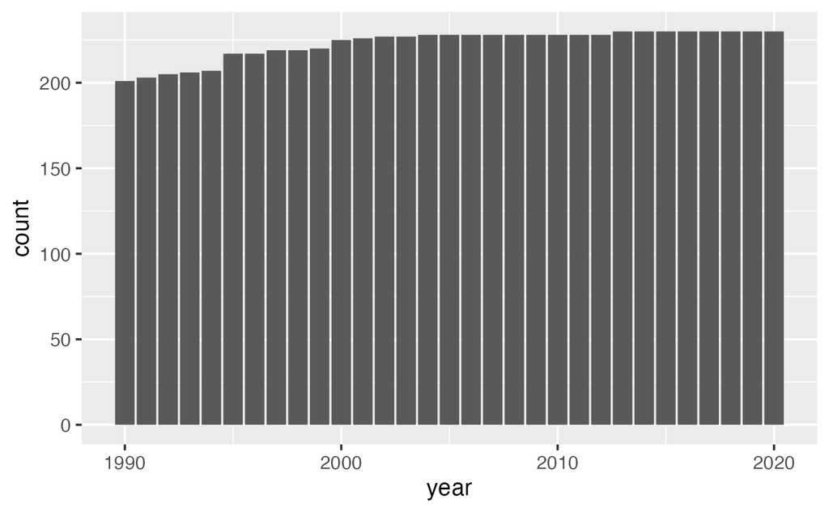

```r
df_co2gdppcap |> drop_na(co2pcap, gdppcap) |>
  ggplot(aes(year)) + geom_bar()
```

Observation:

- The data starts in the year 1990 and ends in 2020. There are data of over 200 countries and regions.

The code above is same as the following.

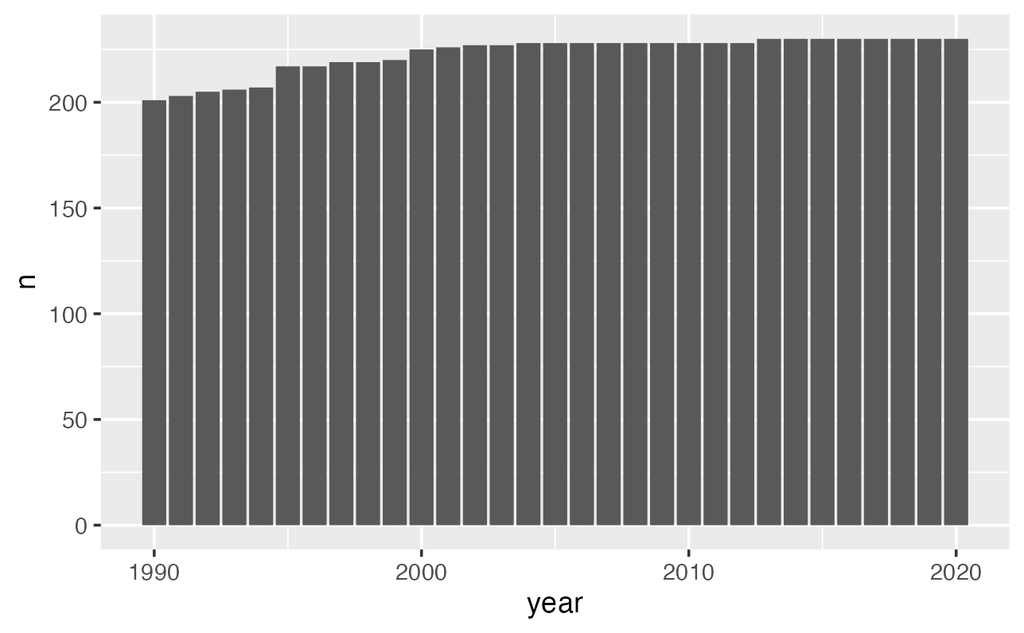

```r
df_co2gdppcap |> drop_na(co2pcap, gdppcap) |>
  group_by(year) |> summarize(n = n()) |>
  ggplot(aes(year, n)) + geom_col()
```

### 2.1.9 Visualization by Line Graphs

#### 2.1.9.1 CO<sub>2</sub> per capita

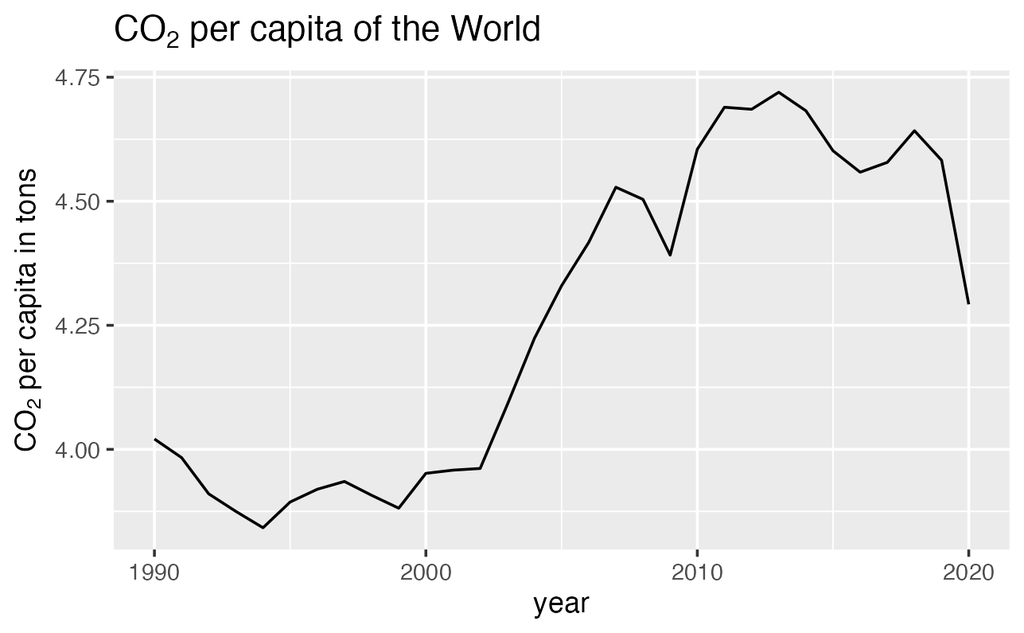

```r
COUNTRY <- "World"
df_co2gdppcap |> filter(country == COUNTRY) |> drop_na(co2pcap) |>
  ggplot(aes(year, co2pcap)) + geom_line() +
  labs(title = expression(paste(CO[2], " per capita of the World")),
       y = expression(paste(CO[2], " per capita in tons")))
```

Observations:

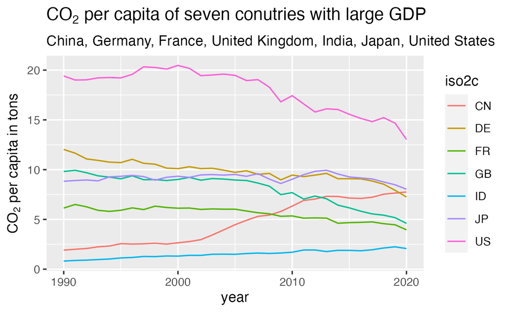

```r
ISO2C <- c("JP", "CN", "ID", "GB", "US", "DE", "FR")
df_co2gdppcap |> filter(iso2c %in% ISO2C) |> drop_na(co2pcap) |>
  ggplot(aes(year, co2pcap, col = iso2c)) + geom_line() +
  labs(title = expression(paste(CO[2], " per capita of seven conutries with large GDP")),
       subtitle = "China, Germany, France, United Kingdom, India, Japan, United States",
       y = expression(paste(CO[2], " per capita in tons")))
```

Observations:

- Need to study more in detail.

#### 2.1.9.2 GDP per capita

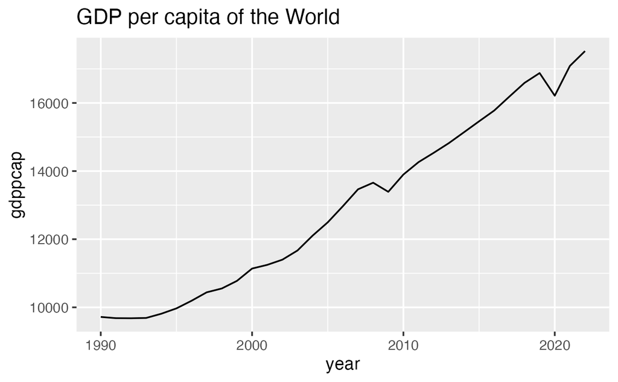

```r
COUNTRY <- "World"
df_co2gdppcap |> filter(country == COUNTRY) |> drop_na(gdppcap) |>
  ggplot(aes(year, gdppcap)) + geom_line() +
  labs(title = "GDP per capita of the World")
```

Observations:

- There are two drops but increasing steadily.

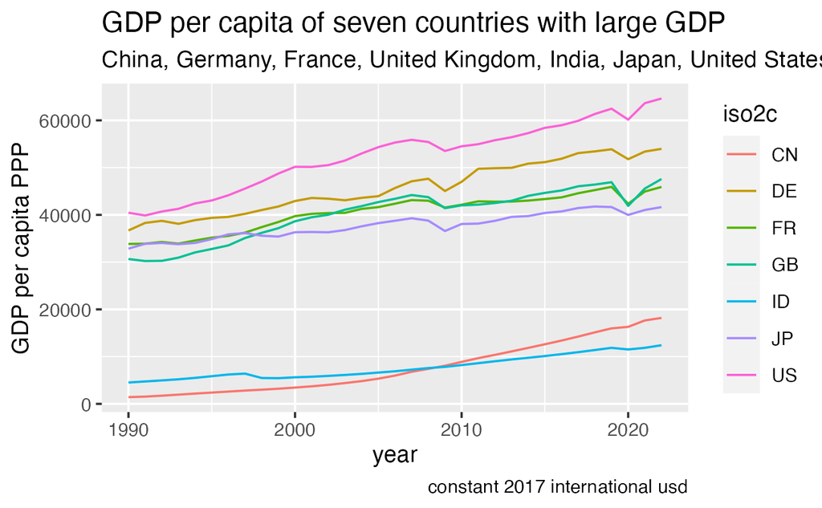

```r
ISO2C <- c("JP", "CN", "ID", "GB", "US", "DE", "FR")
df_co2gdppcap |> filter(iso2c %in% ISO2C) |> drop_na(gdppcap) |>
  ggplot(aes(year, gdppcap, col = iso2c)) + geom_line() +
  labs(title = "GDP per capita of seven countries with large GDP",
       subtitle = "China, Germany, France, United Kingdom, India, Japan, United States",
       y = "GDP per capita PPP",
       caption = "constant 2017 international usd")
```

Observations:

- Need to study each in detail.

#### 2.1.9.3 Ranking of CO<sub>2</sub> per capita

```r
df_co2gdppcap |> filter(year == 2020) |> filter(region != "Aggregates") |>
  drop_na(co2pcap) |> arrange(desc(co2pcap))
```

| country | iso2c | year | co2pcap | gdppcap | region | income |
| --- | --- | --- | --- | --- | --- | --- |
| Qatar | QA | 2020 | 31.72684245 | 89019.0699 | Middle East & North Africa | High income |
| Bahrain | BH | 2020 | 21.97690781 | 47994.4143 | Middle East & North Africa | High income |
| Brunei Darussalam | BN | 2020 | 21.70581244 | 61603.5508 | East Asia & Pacific | High income |
| Kuwait | KW | 2020 | 21.16961025 | 43922.6302 | Middle East & North Africa | High income |
| United Arab Emirates | AE | 2020 | 20.25227168 | 67668.2866 | Middle East & North Africa | High income |
| Oman | OM | 2020 | 15.63620100 | 33098.2099 | Middle East & North Africa | High income |
| Australia | AU | 2020 | 14.77613691 | 48651.7350 | East Asia & Pacific | High income |
| Saudi Arabia | SA | 2020 | 14.26658537 | 44770.9083 | Middle East & North Africa | High income |
| Canada | CA | 2020 | 13.59937492 | 46181.7576 | North America | High income |
| United States | US | 2020 | 13.03282795 | 60158.9105 | North America | High income |

[output cut: 181 more lines]

Observations:

- Many oil producing countries are on the top.

```r
df_co2gdppcap |> filter(year == 2020) |> filter(region != "Aggregates") |>
  drop_na(co2pcap) |> arrange(co2pcap)
```

| country | iso2c | year | co2pcap | gdppcap | region | income |
| --- | --- | --- | --- | --- | --- | --- |
| Congo, Dem. Rep. | CD | 2020 | 0.03258478 | 1044.0712 | Sub-Saharan Africa | Low income |
| Somalia | SO | 2020 | 0.03993465 | 1456.6559 | Sub-Saharan Africa | Low income |
| Central African Republic | CF | 2020 | 0.04428207 | 847.7650 | Sub-Saharan Africa | Low income |
| Burundi | BI | 2020 | 0.05838402 | 711.3553 | Sub-Saharan Africa | Low income |
| Malawi | MW | 2020 | 0.08463616 | 1489.6014 | Sub-Saharan Africa | Low income |
| Niger | NE | 2020 | 0.09032558 | 1214.5410 | Sub-Saharan Africa | Low income |
| Chad | TD | 2020 | 0.09422819 | 1489.1867 | Sub-Saharan Africa | Low income |
| Madagascar | MG | 2020 | 0.09726954 | 1436.2070 | Sub-Saharan Africa | Low income |
| Rwanda | RW | 2020 | 0.10512414 | 2066.4717 | Sub-Saharan Africa | Low income |
| Sierra Leone | SL | 2020 | 0.12727761 | 1586.3549 | Sub-Saharan Africa | Low income |

[output cut: 181 more lines]

**Observations and Questions:**

#### 2.1.9.4 Ranking of GDP per capita

```r
df_co2gdppcap |> filter(year == 2020) |> filter(region != "Aggregates") |>
  drop_na(gdppcap) |> arrange(desc(gdppcap))
```

| country | iso2c | year | co2pcap | gdppcap | region | income |
| --- | --- | --- | --- | --- | --- | --- |
| Luxembourg | LU | 2020 | 12.45695323 | 112274.8179 | Europe & Central Asia | High income |
| Singapore | SG | 2020 | 7.68668370 | 94910.1014 | East Asia & Pacific | High income |
| Ireland | IE | 2020 | 6.76822759 | 91791.4405 | Europe & Central Asia | High income |
| Qatar | QA | 2020 | 31.72684245 | 89019.0699 | Middle East & North Africa | High income |
| Bermuda | BM | 2020 | NA | 76117.8047 | North America | High income |
| Switzerland | CH | 2020 | 4.04207281 | 67928.1915 | Europe & Central Asia | High income |
| United Arab Emirates | AE | 2020 | 20.25227168 | 67668.2866 | Middle East & North Africa | High income |
| Cayman Islands | KY | 2020 | NA | 67530.6955 | Latin America & Caribbean | High income |
| Norway | NO | 2020 | 6.72508005 | 63776.1610 | Europe & Central Asia | High income |
| Brunei Darussalam | BN | 2020 | 21.70581244 | 61603.5508 | East Asia & Pacific | High income |

[output cut: 184 more lines]

Observations:

- Interesting. I know the ranking of GDP but not GDP per capita.

```r
df_co2gdppcap |> filter(year == 2020) |> filter(region != "Aggregates") |>
  drop_na(gdppcap) |> arrange(gdppcap)
```

| country | iso2c | year | co2pcap | gdppcap | region | income |
| --- | --- | --- | --- | --- | --- | --- |
| Burundi | BI | 2020 | 0.05838402 | 711.3553 | Sub-Saharan Africa | Low income |
| Central African Republic | CF | 2020 | 0.04428207 | 847.7650 | Sub-Saharan Africa | Low income |
| Congo, Dem. Rep. | CD | 2020 | 0.03258478 | 1044.0712 | Sub-Saharan Africa | Low income |
| Niger | NE | 2020 | 0.09032558 | 1214.5410 | Sub-Saharan Africa | Low income |
| Mozambique | MZ | 2020 | 0.22276755 | 1237.9460 | Sub-Saharan Africa | Low income |
| Liberia | LR | 2020 | 0.23183892 | 1383.8281 | Sub-Saharan Africa | Low income |
| Madagascar | MG | 2020 | 0.09726954 | 1436.2070 | Sub-Saharan Africa | Low income |
| Somalia | SO | 2020 | 0.03993465 | 1456.6559 | Sub-Saharan Africa | Low income |
| Chad | TD | 2020 | 0.09422819 | 1489.1867 | Sub-Saharan Africa | Low income |
| Malawi | MW | 2020 | 0.08463616 | 1489.6014 | Sub-Saharan Africa | Low income |

[output cut: 184 more lines]

Observations:

- Top 10 is about 100 times the bottom 10.

### 2.1.10 Histograms and Boxplots for Variation

#### 2.1.10.1 CO<sub>2</sub> per capita

*Change the bins or binwidth.*

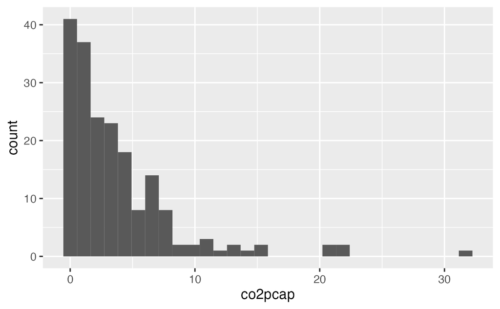

```r
df_co2gdppcap |> filter(year == 2020) |>
  filter(region != "Aggregates") |> drop_na(co2pcap) |>
  ggplot(aes(co2pcap)) + geom_histogram()
```

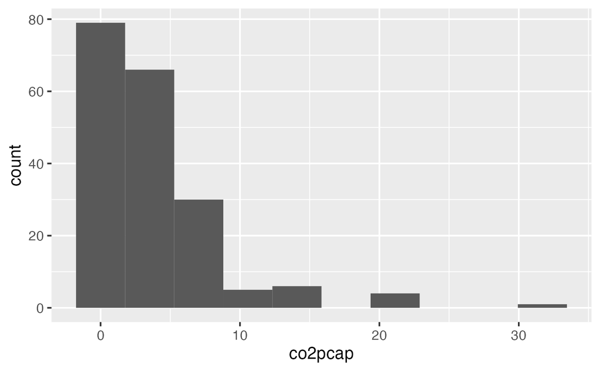

```r
df_co2gdppcap |> filter(year == 2020) |>
  filter(region != "Aggregates") |> drop_na(co2pcap) |>
  ggplot(aes(co2pcap)) + geom_histogram(bins = 10)
```

Observations:

- For most of the countries, the value is less than 5 tons per person per year.

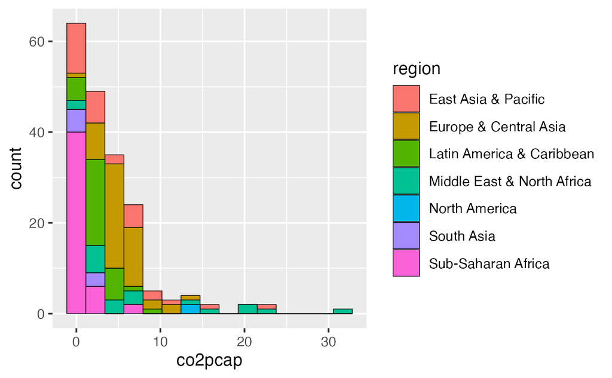

```r
df_co2gdppcap |> filter(year == 2020) |>
  filter(region != "Aggregates") |> drop_na(co2pcap) |>
  ggplot(aes(co2pcap, fill = region)) + geom_histogram(bins = 15, col = "black", linewidth = 0.2)
```

Observations:

- Interesting but complicated.

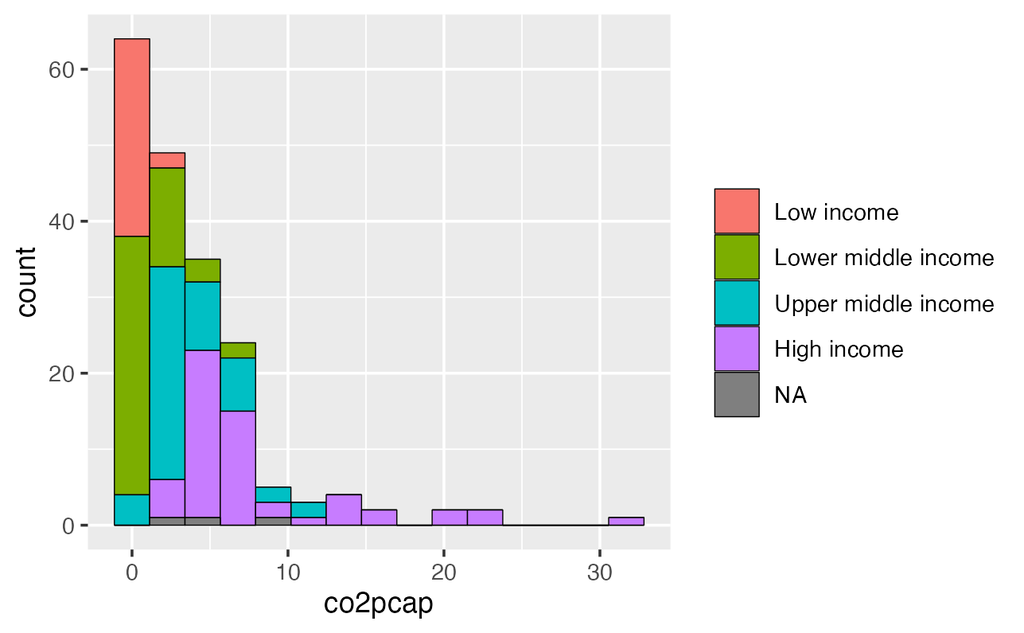

```r
df_co2gdppcap |> filter(year == 2020) |>
  filter(region != "Aggregates") |> drop_na(co2pcap) |>
  ggplot(aes(co2pcap, fill = factor(income, levels = INCOME))) + geom_histogram(bins = 15, col = "black", linewidth = 0.2) +
  labs(fill = "")
```

**Observations and Questions:**

- High income countries have larger values in general.

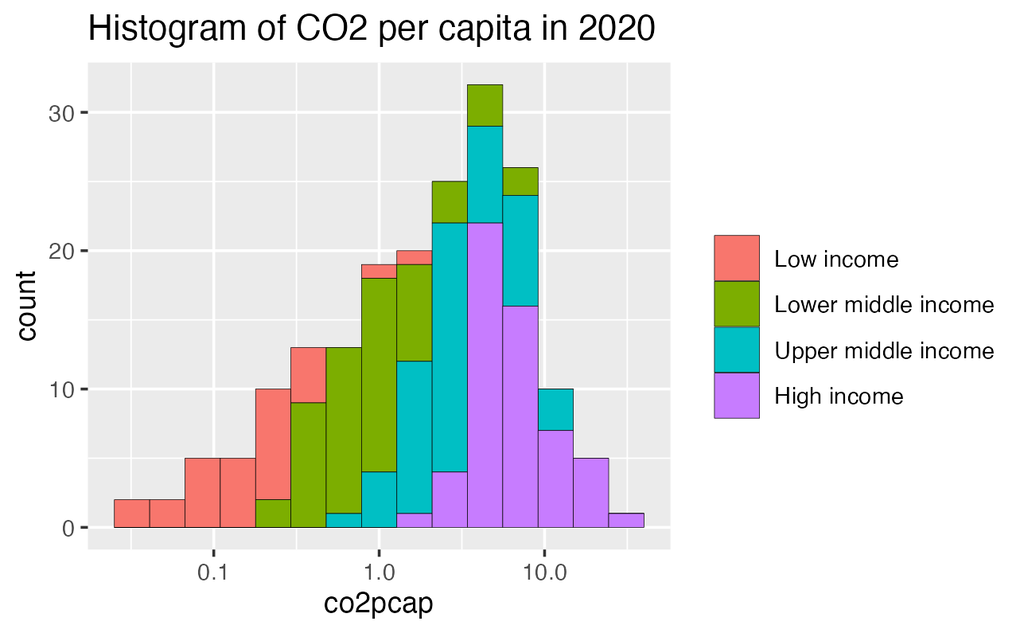

```r
df_co2gdppcap |> filter(year == 2020) |> filter(region != "Aggregates") |>
  drop_na(co2pcap) |> filter(income != "Not classified") |>
  ggplot(aes(co2pcap, fill = factor(income, levels = INCOME))) + geom_histogram(bins = 15, col = "black", linewidth = 0.1) +
  scale_x_log10() +
  labs(title = "Histogram of CO2 per capita in 2020", fill = "")
```

Observations:

- Each of log10 scale and the raw value seems to tell different feature.
- Need to consider NA value in income.

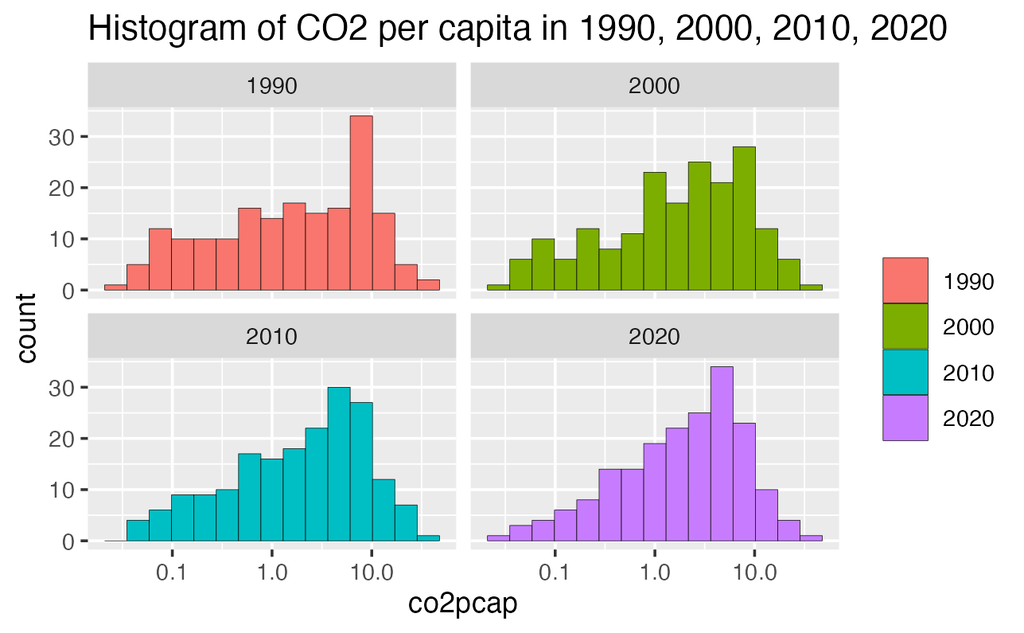

```r
df_co2gdppcap |> filter(year %in% c(1990, 2000, 2010, 2020)) |> filter(region != "Aggregates") |>
  drop_na(co2pcap) |> filter(co2pcap > 0) |> filter(income != "Not classified") |>
  ggplot(aes(co2pcap, fill = factor(year))) +
  geom_histogram(bins = 15, col = "black", linewidth = 0.1) +
  scale_x_log10() + facet_wrap(~year) +
  labs(title = "Histogram of CO2 per capita in 1990, 2000, 2010, 2020", fill = "")
```

Observations:

- Want old data, but can see differences.

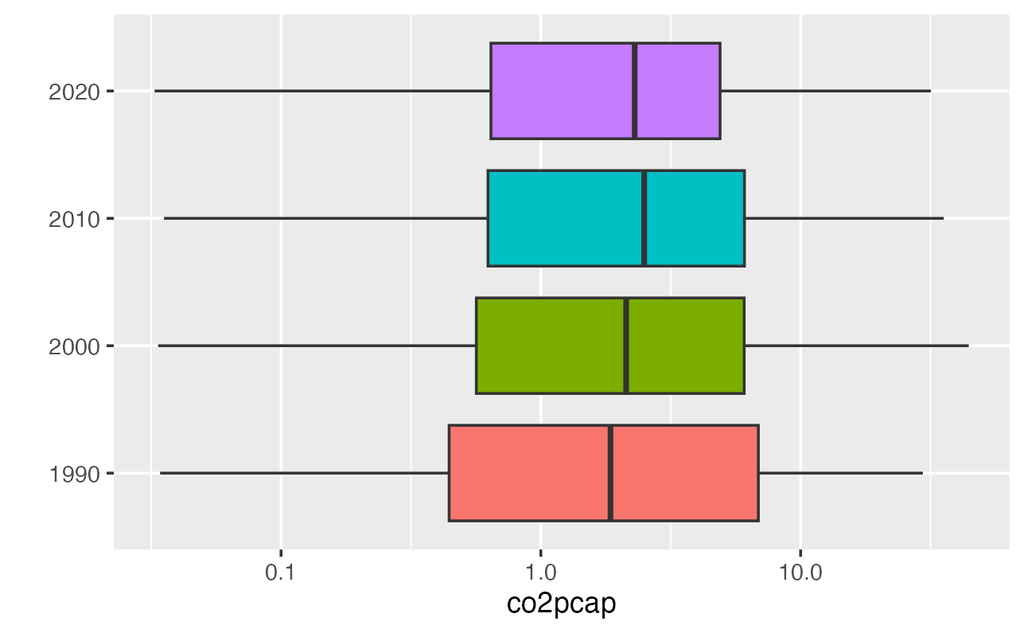

```r
df_co2gdppcap |> filter(year %in% c(1990, 2000, 2010, 2020)) |> filter(region != "Aggregates") |>
  drop_na(co2pcap) |> filter(co2pcap > 0) |> filter(income != "Not classified") |>
  ggplot(aes(co2pcap, factor(year), fill = factor(year))) +
  geom_boxplot() + scale_x_log10() + labs(y = "") + theme(legend.position = "none")
```

Observations:

- Not much different but the width is decreasing.

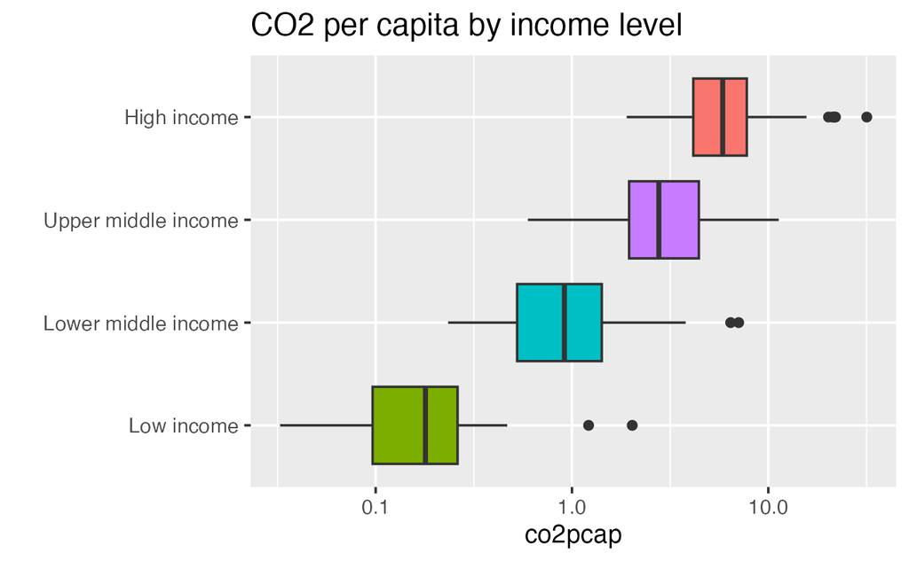

```r
df_co2gdppcap |> filter(year == 2020) |> filter(region != "Aggregates") |>
  drop_na(co2pcap) |> filter(co2pcap > 0) |> filter(income != "Not classified") |>
  ggplot(aes(co2pcap, factor(income, levels = INCOME), fill = income)) +
  geom_boxplot() + scale_x_log10() +
  labs(title = "CO2 per capita by income level", y = "", fill = "") +
  theme(legend.position = "none")
```

Observations:

- The result looks natural. However, it is worth analysing outliers in detail.

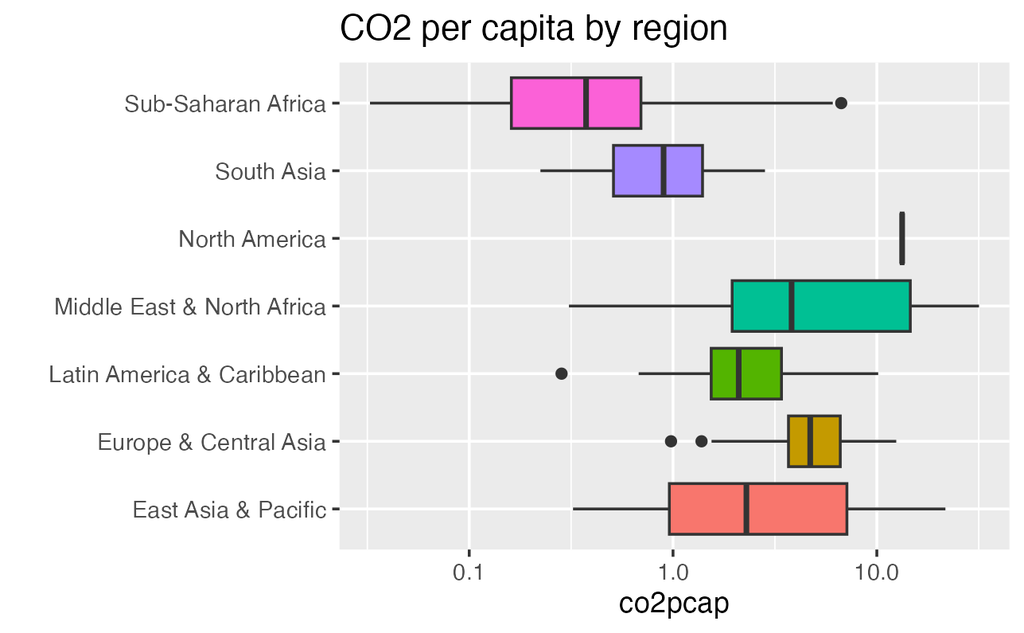

```r
df_co2gdppcap |> filter(year == 2020) |> filter(region != "Aggregates") |>
  drop_na(co2pcap) |> filter(co2pcap > 0) |>
  ggplot(aes(co2pcap, region, fill = region)) +
  geom_boxplot() + scale_x_log10() +
  labs(title = "CO2 per capita by region", y = "", fill = "") +
  theme(legend.position = "none")
```

Observations:

- Need to investigate each region closely.

#### 2.1.10.2 GDP per capita

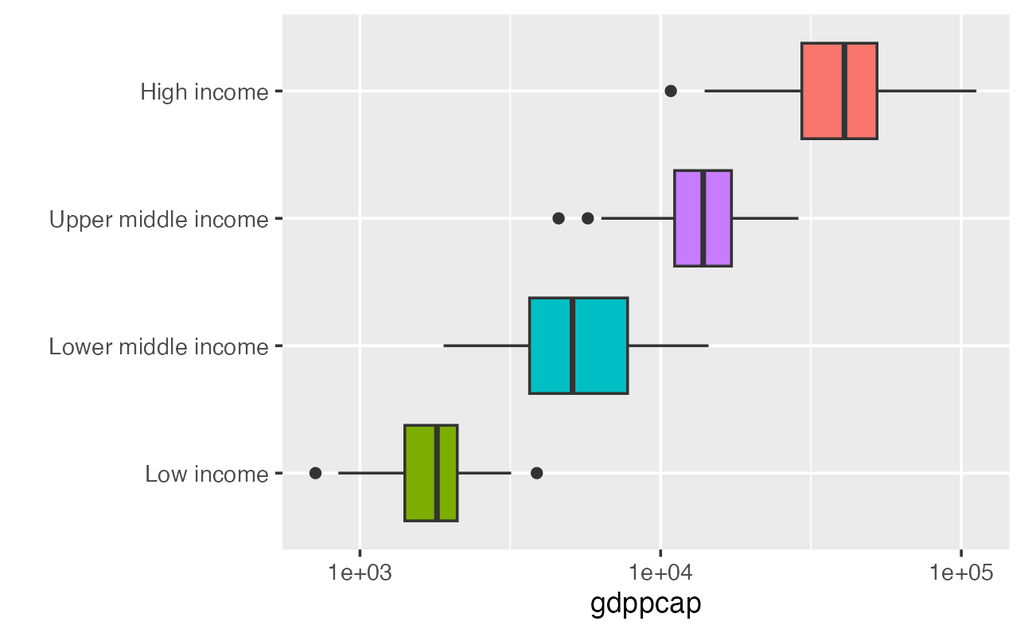

```r
df_co2gdppcap |> filter(year == 2020) |>
  filter(region != "Aggregates", !is.na(income)) |>
  drop_na(gdppcap) |> ggplot(aes(gdppcap, factor(income, levels = INCOME), fill = income)) + geom_boxplot() + scale_x_log10() + theme(legend.position = "none") + labs(y = "")
```

Observations:

- There are overlaps. Need to study how the income level is determined by World Bank.
  - How does the World Bank classify countries? [[Link](https://datahelpdesk.worldbank.org/knowledgebase/articles/378834-how-does-the-world-bank-classify-countries)]

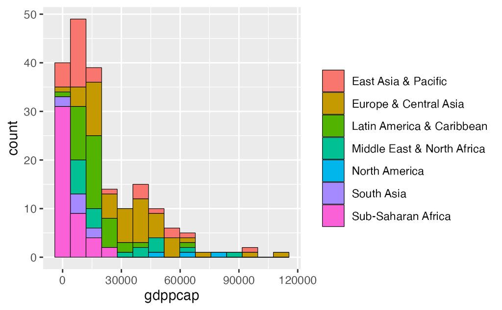

```r
df_co2gdppcap |> filter(year == 2020) |>
  filter(region != "Aggregates", !is.na(region)) |>
  drop_na(gdppcap) |>
  ggplot(aes(gdppcap, fill = region)) + geom_histogram(bins = 15, col = "black", linewidth = 0.2) +
  labs(fill = "")
```

Observations:

- Interesting but complicated.

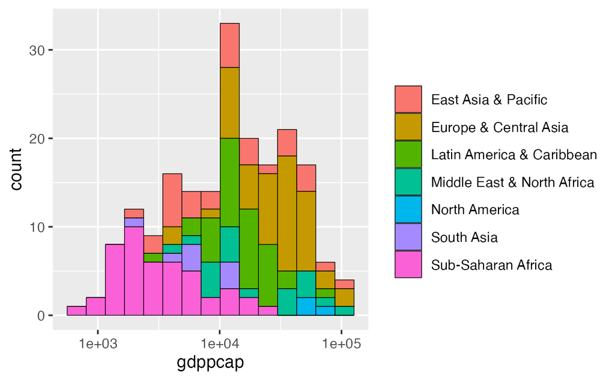

```r
df_co2gdppcap |> filter(year == 2020) |>
  filter(region != "Aggregates", !is.na(region)) |>
  drop_na(gdppcap) |>
  ggplot(aes(gdppcap, fill = region)) + geom_histogram(bins = 15, col = "black", linewidth = 0.2) + scale_x_log10() +
  labs(fill = "")
```

Observations:

- Two scales give different information and impression.

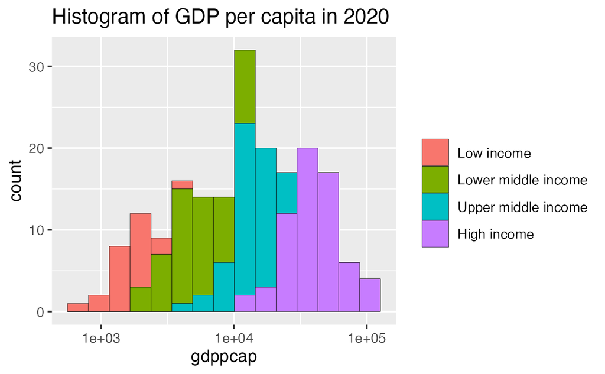

```r
df_co2gdppcap |> filter(year == 2020) |> filter(region != "Aggregates") |>
  drop_na(gdppcap) |> filter(income != "Not classified") |>
  ggplot(aes(gdppcap, fill = factor(income, levels = INCOME))) + geom_histogram(bins = 15, col = "black", linewidth = 0.1) +
  scale_x_log10() +
  labs(title = "Histogram of GDP per capita in 2020", fill = "")
```

Observations:

- Need to study overlaps.

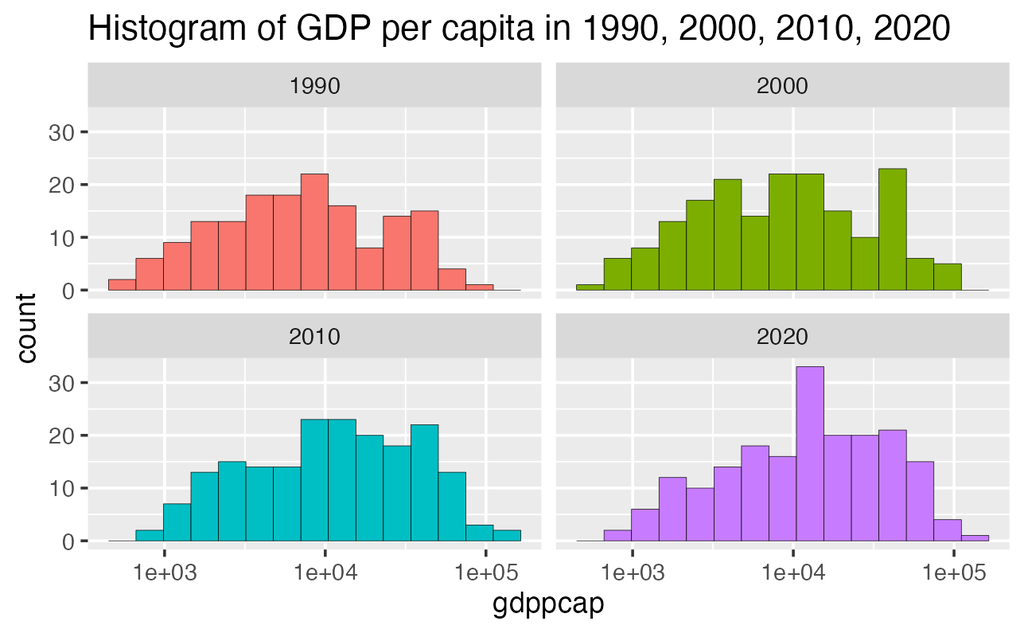

```r
df_co2gdppcap |> filter(year %in% c(1990, 2000, 2010, 2020)) |> filter(region != "Aggregates") |>
  drop_na(gdppcap) |> filter(gdppcap > 0) |> filter(income != "Not classified") |>
  ggplot(aes(gdppcap, fill = factor(year))) +
  geom_histogram(bins = 15, col = "black", linewidth = 0.1) +
  scale_x_log10() + facet_wrap(~year) +
  labs(title = "Histogram of GDP per capita in 1990, 2000, 2010, 2020", fill = "") +
  theme(legend.position = "none")
```

Observations:

- Cannot see a big difference.

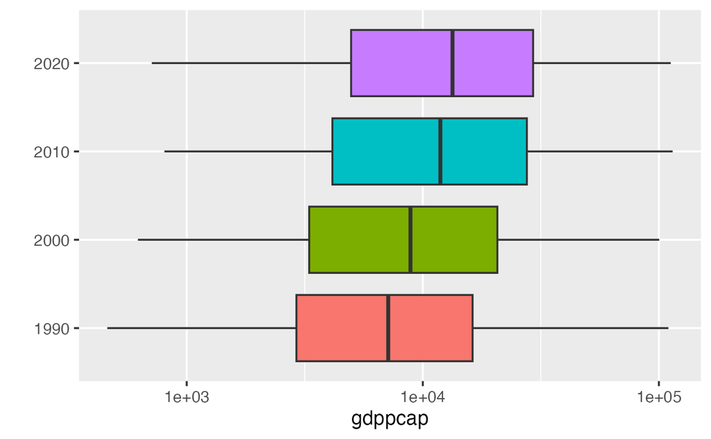

Observations:

[figure not shown]

Observations:

- Can see a trend.

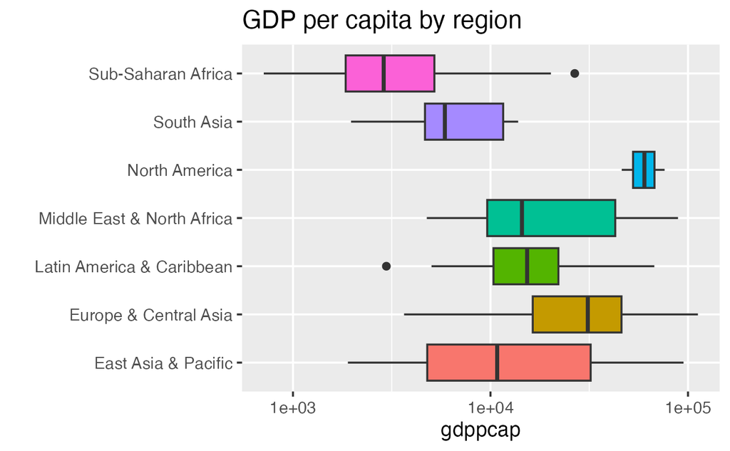

```r
df_co2gdppcap |> filter(year == 2020) |> filter(region != "Aggregates") |>
  drop_na(gdppcap) |> filter(gdppcap > 0) |>
  ggplot(aes(gdppcap, region, fill = region)) +
  geom_boxplot() + scale_x_log10() +
  labs(title = "GDP per capita by region", y = "", fill = "") +
  theme(legend.position = "none")
```

Observations:

- What is the best way to look at regional differences?

### 2.1.11 Scatterplot for Covariation

#### 2.1.11.1 Scatterplot with a regression line

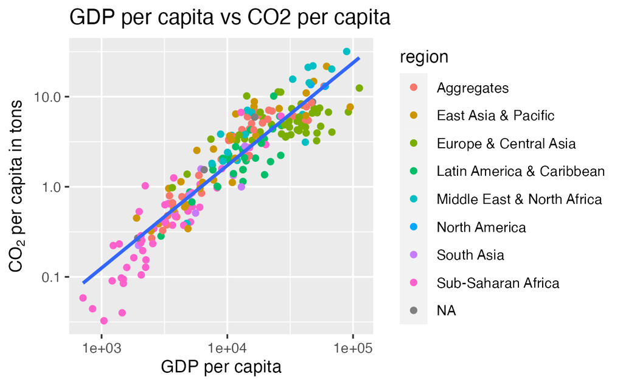

```r
df_co2gdppcap |> filter(year == 2020) |>
  drop_na(gdppcap, co2pcap) |>
  ggplot(aes(gdppcap, co2pcap)) + geom_point(aes(col = region)) +
  geom_smooth(method = "lm", formula = 'y~x', se = FALSE) +
  scale_x_log10() + scale_y_log10() +
  labs(title = "GDP per capita vs CO2 per capita",
       x = "GDP per capita",
       y = expression(paste(CO[2], " per capita in tons")))
```

Observations:

- GDP per capita in log10 scale and Co2 per capita relates positively and the regression line looks well-fit.

#### 2.1.11.2 Summary of a linear model

*You will learn how to interprete the values below later in this course.*

```r
df_co2gdppcap |> filter(year == 2020) |> drop_na(gdppcap, co2pcap) |>
  lm(log10(co2pcap)~log10(gdppcap), data = _) |> summary()
```

```
Call:
lm(formula = log10(co2pcap) ~ log10(gdppcap), data = drop_na(filter(df_co2gdppcap,
    year == 2020), gdppcap, co2pcap))

Residuals:
     Min       1Q   Median       3Q      Max
-0.68315 -0.15741 -0.00445  0.16201  0.59504

Coefficients:
               Estimate Std. Error t value Pr(>|t|)
(Intercept)    -4.31720    0.13473  -32.04   <2e-16 ***
log10(gdppcap)  1.13857    0.03309   34.41   <2e-16 ***
---
Signif. codes:  0 ‘***’ 0.001 ‘**’ 0.01 ‘*’ 0.05 ‘.’ 0.1 ‘ ’ 1

Residual standard error: 0.2375 on 228 degrees of freedom
Multiple R-squared:  0.8385,    Adjusted R-squared:  0.8378
F-statistic:  1184 on 1 and 228 DF,  p-value: < 2.2e-16
```

Observations:

- In log10 scale, the regression line fits well with slope 1.1.
- Multiple R-square is 0.84 and the linear regression explains good part of the relation of these data.

# 3 Your Project

## 3.1 Title of your project

We study …..

1. Name of the indicator 1: Indicator Code 1
- Description:
2. Name of the indicator 2: Indicator Code 2
- Description:

### 3.1.1 Importing Data

Edit the following code chunk!

```r
chosen_indicator_1 <- "SE.SEC.ENRR"
short_name_1 <- "sec"
chosen_indicator_2 <- "NY.GDP.PCAP.PP.KD"
short_name_2 <- "gdppcap"
```

```r
df_yourdata <- WDI(indicator = c(short_name_1 = chosen_indicator_1,
                                 short_name_2 = chosen_indicator_2),
                 extra = TRUE, cache = wdicache)
```

```r
write_csv(df_yourdata, "data/yourdata.csv")
```

```r
df_yourdata <- read_csv("data/yourdata.csv")
```

### 3.1.2 Visualization by Line Graphs

#### 3.1.2.1 Name of the Indicator 1

Edit the title and the label of y-axis.

```r
COUNTRY <- "World"
df_yourdata |> filter(country == COUNTRY) |> drop_na(short_name_1) |>
  ggplot(aes(year, short_name_1)) + geom_line() +
  labs(title = "",
       y = "")
```

**Observations and Questions:**

Edit ISO2C, title, subtitle, and the label of y-axis.

**Observations and Questions:**

#### 3.1.2.2 Name of the Indicator 2

Edit COUNTRY and the title.

**Observations and Questions:**

Edit ISO2C, title, subtitle, and the label of y-axis, and add caption if preferable.

**Observations and Questions:**

#### 3.1.2.3 Ranking of the indicator 1

Edit year if necessary.

**Observations and Questions:**

#### 3.1.2.4 Ranking of the Indicator 2

**Observations and Questions:**

**Observations and Questions:**

### 3.1.3 Histograms and Boxplots for Variation

#### 3.1.3.1 Name of the Indicator 1

Edit the title and year.

**Observations and Questions:**

Edit the title and the years.

**Observations and Questions:**

**Observations and Questions:**

Edit the title, and the year if necessary.

**Observations and Questions:**

Edit the title and year if necessary.

**Observations and Questions:**

#### 3.1.3.2 GDP per capita

Edit the title, and year if necessary. Edit the title and the year if necessary.

**Observations and Questions:**

**Observations and Questions:**

Edit the title, and the year if necessary.

**Observations and Questions:**

Edit the title and the year if necessary.

### 3.1.4 Scatterplot for Covariation

#### 3.1.4.1 Scatterplot with a regression line

Edit the title, the labels of x- and y- axes.

**Observations and Questions:**

#### 3.1.4.2 Summary of a linear model

Edit year if necessary.

**Observations and Questions:**